# Background Analysis

In a Stroop task, participants are presented with a list of words, with each word displayed in a color of ink. The participant’s task is to say out loud the color of the ink in which the word is printed. The task has two conditions: a congruent words condition, and an incongruent words condition. In the congruent words condition, the words being displayed are color words whose names match the colors in which they are printed: for example RED, BLUE. In the incongruent words condition, the words displayed are color words whose names do not match the colors in which they are printed: for example PURPLE, ORANGE. In each case, we measure the time it takes to name the ink colors in equally-sized lists. Each participant will go through and record a time from each condition.

## Analysis

**Question:1** What is our independent variable? What is our dependent variable?

**Answer:** Independent variables are those variables which aren't affect on anything that I do except dependent variables. We can choose independent variables by ourself. It isn't change by changing other variables. In an experiment, we usually choose that independent variables which will affect dependent variables to get or predict the values of dependent variables.

The Dependent variables refer to the variable which will measure the affect on the Independent variables. In a simple language, we can say that the dependent variables are those variables which totally dependent on Independent variables but it doesn't mean that Dependent variable could cause a change in Independent variable.

In this experiment, the response time a person takes to read the color name is Dependent Variable. Independent variable is whether a text is congruent to text-color or not.

**Question:2** What is an appropriate set of hypotheses for this task? What kind of statistical test do you expect to perform? Justify your choices.

**Answer:** In this experiment, we'll choose a two tailed **depedent** (paired) t-test. The reason of choosing a two tailed test is, there is no information in the question that we have to tell that a congruent test will improve response time or reduce the response time. The reason of choosing a t-test is, we don't know the whole population. We have a sample of size 24 only which is less than 30. A Stroop effect is a test only, so using t-test will be beneficial for us to compare the means of two groups for pre-test and post-test.

Here are some *Assumptions*:-

The distribution differences of the congruent and incongruent variables are approximately Normal Distributed. Normal Distribution is a bell-shaped distribution in which Mean, Median and Mode are approximately same.

The observations should be independent to each other.

Their should not be any outliers in the distribution differences between two groups.

Confidence Level is 95% means α = 0.05

### Types of Hypothesis

**Null Hypothesis:** Population Mean of Congruent (μ<sub>congruent</sub>) = Population Mean of Incongruent (μ<sub>incongruent</sub>) ($H_0:$ μ<sub>c</sub> = μ<sub>i</sub> )  
A hypothesis in which there is no significant difference between the means of two groups. If two set of variables has approximately no significant difference, it means that retain or fail to reject the Null Hypothesis. Denoted by $H_0$.

**Alternative Hypothesis:** Population Mean of Congruent (μ<sub>congruent</sub>) ≠ Population Mean of Incongruent (μ<sub>incongruent</sub>) ($H_a:$ μ<sub>c</sub> ≠ μ<sub>i</sub>)  
A hypothesis in which there is a significant difference between the means of two groups. It means that the response time of the congruent sample is not equal or different to the response time of Incongruent sample. Denoted by $H_a$.

Where μ<sub>c</sub> = Mean response time for naming the congruent words  
μ<sub>i</sub> = Mean response time for naming the incongruent words

We can reject Null Hypothesis (Retain Alternative Hypothesis), if we get a significant difference between the mean of congruent words and incongruent words to the colors and vice-versa.

**Question:3** Report some descriptive statistics regarding this dataset. Include at least one measure of central tendency and at least one measure of variability?

**Answer :**

```python
#Importing the Libraries
import math
import matplotlib.pyplot as plt
import pandas as pd
import numpy as np
import seaborn as sns
from scipy.stats import t
```

```python
#Magic Function, to set the backend as Inline
%matplotlib inline

#reading the file and printing the data
data = pd.read_csv("stroopdata.csv")
data
```

|  | Congruent | Incongruent |
| --- | --- | --- |
| 0 | 12.079 | 19.278 |
| 1 | 16.791 | 18.741 |
| 2 | 9.564 | 21.214 |
| 3 | 8.630 | 15.687 |
| 4 | 14.669 | 22.803 |
| 5 | 12.238 | 20.878 |
| 6 | 14.692 | 24.572 |
| 7 | 8.987 | 17.394 |
| 8 | 9.401 | 20.762 |
| 9 | 14.480 | 26.282 |
| 10 | 22.328 | 24.524 |
| 11 | 15.298 | 18.644 |
| 12 | 15.073 | 17.510 |
| 13 | 16.929 | 20.330 |
| 14 | 18.200 | 35.255 |
| 15 | 12.130 | 22.158 |
| 16 | 18.495 | 25.139 |
| 17 | 10.639 | 20.429 |
| 18 | 11.344 | 17.425 |
| 19 | 12.369 | 34.288 |
| 20 | 12.944 | 23.894 |
| 21 | 14.233 | 17.960 |
| 22 | 19.710 | 22.058 |
| 23 | 16.004 | 21.157 |

```python
#Calculating Sample Size for both the columns
con_size = len(data['Congruent'])
incon_size = len(data["Incongruent"])

#Calculating Median
con_median = data['Congruent'].median()
incon_median = data['Incongruent'].median()

#Calculating Standard Deviations
con_std = data['Congruent'].std()
incon_std = data['Incongruent'].std()

#Assigning the data using dataframe and priting it in a tabular form
data_dict = {'Congruent':[con_size,con_median,con_std],'Incongruent':[incon_size,incon_median,incon_std]}
df = pd.DataFrame(data=data_dict,index=["Sample Size","Median","Standard Deviation"])
df
```

|  | Congruent | Incongruent |
| --- | --- | --- |
| Sample Size | 24.000000 | 24.000000 |
| Median | 14.356500 | 21.017500 |
| Standard Deviation | 3.559358 | 4.797057 |

```python
#Printing all the details
data.describe()
```

|  | Congruent | Incongruent |
| --- | --- | --- |
| count | 24.000000 | 24.000000 |
| mean | 14.051125 | 22.015917 |
| std | 3.559358 | 4.797057 |
| min | 8.630000 | 15.687000 |
| 25% | 11.895250 | 18.716750 |
| 50% | 14.356500 | 21.017500 |
| 75% | 16.200750 | 24.051500 |
| max | 22.328000 | 35.255000 |

**Question: 4** Provide one or two visualizations that show the distribution of the sample data. Write one or two sentences noting what you observe about the plot or plots?

**Answer:**

```
Text(0.5,1,'Difference of Congruent and Incongruent')
```

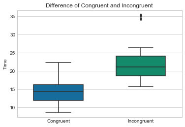

```python
#Plotting the graph using BoxPlot
sns.set_style('whitegrid')
sns.boxplot(data=data[['Congruent','Incongruent']],orient="v",width=0.6,palette="colorblind",fliersize=5)
plt.ylabel('Time')
plt.title('Difference of Congruent and Incongruent')
```

**Outcome of BoxPlot :**

The BoxPlot clearly shows the difference between the medians. The median is approximately 14.5 for Congruent and 21 for Incongruent datasets.

We can see the minimum=8.6 and maximum=22 values for Congruent AND minimum=15.6 and maximum=35 values for Incongruent.

We can also observe the range between 25% to 75% for both the datasets.

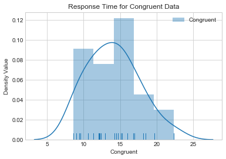

```python
#Graph for Congruent Dataset
sns.distplot(data['Congruent'],rug='true',label="Congruent")
plt.title('Response Time for Congruent Data')
plt.ylabel('Density Value')
plt.legend()
```

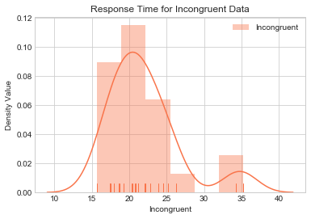

```python
#Graph for Incongruent Dataset
sns.distplot(data['Incongruent'],rug='true',label="Incongruent",color="#F9744A")
plt.title('Response Time for Incongruent Data')
plt.ylabel('Density Value')
plt.legend()
```

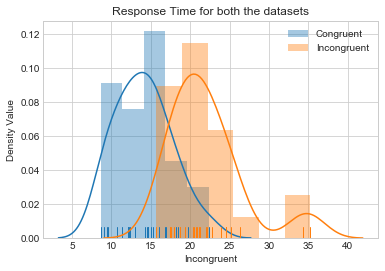

```python
#Graph for both the datasets
sns.distplot(data['Congruent'],rug='true',label="Congruent")
sns.distplot(data['Incongruent'],rug='true',label="Incongruent")
plt.title('Response Time for both the datasets')
plt.ylabel('Density Value')
plt.legend()
```

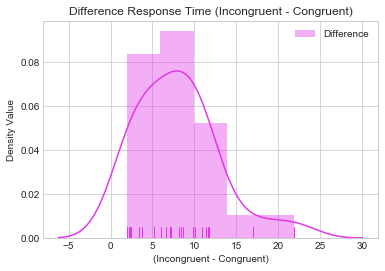

```python
#Graph for Difference of the datasets (Incongruent - Congruent)
sns.distplot(data['Incongruent']-data['Congruent'],rug='true',label="Difference",color='#E038E8')
plt.title('Difference Response Time (Incongruent - Congruent)')
plt.xlabel('(Incongruent - Congruent)')
plt.ylabel('Density Value')
plt.legend()
```

**Question:5** Now, perform the statistical test and report your results. What is your confidence level and your critical statistic value? Do you reject the null hypothesis or fail to reject it? Come to a conclusion in terms of the experiment task. Did the results match up with your expectations?

**Answer:**

```python
#Finding t-critical value for two-tailed test of 95% Confidence Level and DF = 23
t_critical = round(t.ppf(0.975,23),3)
print('t-critical value : ',t_critical)
```

```
t-critical value :  2.069
```

```python
#Difference of Incongruent and Congruent
data['Difference'] = data['Incongruent'] - data['Congruent']
data
```

|  | Congruent | Incongruent | Difference |
| --- | --- | --- | --- |
| 0 | 12.079 | 19.278 | 7.199 |
| 1 | 16.791 | 18.741 | 1.950 |
| 2 | 9.564 | 21.214 | 11.650 |
| 3 | 8.630 | 15.687 | 7.057 |
| 4 | 14.669 | 22.803 | 8.134 |
| 5 | 12.238 | 20.878 | 8.640 |
| 6 | 14.692 | 24.572 | 9.880 |
| 7 | 8.987 | 17.394 | 8.407 |
| 8 | 9.401 | 20.762 | 11.361 |
| 9 | 14.480 | 26.282 | 11.802 |
| 10 | 22.328 | 24.524 | 2.196 |
| 11 | 15.298 | 18.644 | 3.346 |
| 12 | 15.073 | 17.510 | 2.437 |
| 13 | 16.929 | 20.330 | 3.401 |
| 14 | 18.200 | 35.255 | 17.055 |
| 15 | 12.130 | 22.158 | 10.028 |
| 16 | 18.495 | 25.139 | 6.644 |
| 17 | 10.639 | 20.429 | 9.790 |
| 18 | 11.344 | 17.425 | 6.081 |
| 19 | 12.369 | 34.288 | 21.919 |
| 20 | 12.944 | 23.894 | 10.950 |
| 21 | 14.233 | 17.960 | 3.727 |
| 22 | 19.710 | 22.058 | 2.348 |
| 23 | 16.004 | 21.157 | 5.153 |

```python
# Mean of Difference
diff_mean = data['Difference'].mean()
print('Mean of Difference : ',round(diff_mean,3))

#Standard Deviation of Difference
diff_std = data['Difference'].std()
print('Standard Deviation of Difference : ',round(diff_std,3))

# Sampling Error
SE = round(diff_std/math.sqrt(24),3)
print('Sample Error : ',SE)

# Confidence Interval
CI_lower = round(diff_mean-(t_critical*SE),3)
CI_upper = round(diff_mean+(t_critical*SE),3)
print('Confidence Interval (CI) : ( '+str(CI_lower)+', '+str(CI_upper)+' )')

# t-statistic value
t_stats = round(diff_mean/SE,3)
print('t-statistic value : ',t_stats)
```

```
Mean of Difference :  7.965
Standard Deviation of Difference :  4.865
Sample Error :  0.993
Confidence Interval (CI) : ( 5.91, 10.019 )
t-statistic value :  8.021
```

**Values:-**

Confidence Level : 95%

Sample Size : 24

Degree of Freedom : 23

t-critical value : ∓ 2.069

Mean : 7.965

Standard Deviation : 4.865

Sample Error : 0.993

Confidence Interval : (5.91, 10.019)

t-statistic value : 8.021

**Results:-**

We find that the t-statistic value is 8.021 for the difference of Incongruent response time and Congruent response time which far greater that the critical values (∓2.069) so that we can say that the t-statistic value is in the critical region.

Since the t-statistic value is in the critical region, So we **Reject the Null Hypothesis** because there is a significant difference in Incongruent and Congruent's response time. It means that the response time taken to read the text with same color is less than the time taken to read the text with Incongruent color.

With the help of Confidence Interval, we can say that the mean differrence of the whole population should be within 5.91 to 10.019

**Question:6** What do you think is responsible for the effects observed? Can you think of an alternative or similar task that would result in a similar effect? Some research about the problem will be helpful for thinking about these two questions?

**Answer:** The studies have shown that the human brain is trained from a very young age to recognize words. The more often brain sees the certain words, the faster the person able to read it. The words themselves have a strong influence over your ability to say the color. We encounter words on such a persistent basis that the reading occur almost effortlessly whereas declaration of a color requires more effort. When there is a conflict between these two sources of information, our cognitive load is increased, and our brains have to work harder to resolve the required difference that's why it takes more time to say the color name written with different color name.

The alternative task that would result in a similar effect is:-  
We can color only half of the word with same color name for first level and again color half of the word with different color name in second level and calculate the response time to read the color name.